# Analisi Top 5000 album nella storia

2023-05-30

## Intro

Questo studio di dati andrà ad analizzare quella che è la classifica dei top 5000 album nel mondo. Utilizzeremo un dataset trovato su Kaggle, basato sulle classifiche di Spotify.

## Spotify

Spotify è un noto servizio musicale di streaming svedese, si tratta di uno dei servizi di streaming più utilizzati dal pubblico, grazie alla sua semplicità di utilizzo e ai suoi algoritmi che permettono all’utente di scoprire nuova musica basandosi sugli ascolti precedenti, attraverso la creazione di playlist mix costruite appositamente per il consumatore.

[figure not shown]

Ad Aprile 2023 conta oltre 515 milioni di utenti, di cui oltre 200 milioni usano la versione premium.

## Cosa andremo ad analizzare?

Questo studio verterà l’analisi della top 5000 album più venduti e riprodotti al mondo, gli obiettivi sono:

- Confrontare i generi degli album
- Vedere quali sono gli artisti che appaiono più volte nella classifica
- Vedere quali sono le fasce di anni in cui sono presenti più album in classifica
- E tanto altro…

## Quali sono gli artisti più presenti nella Top?

Di seguito troviamo un grafico rappresentante i 10 aritisti presenti più volte nella classifica.

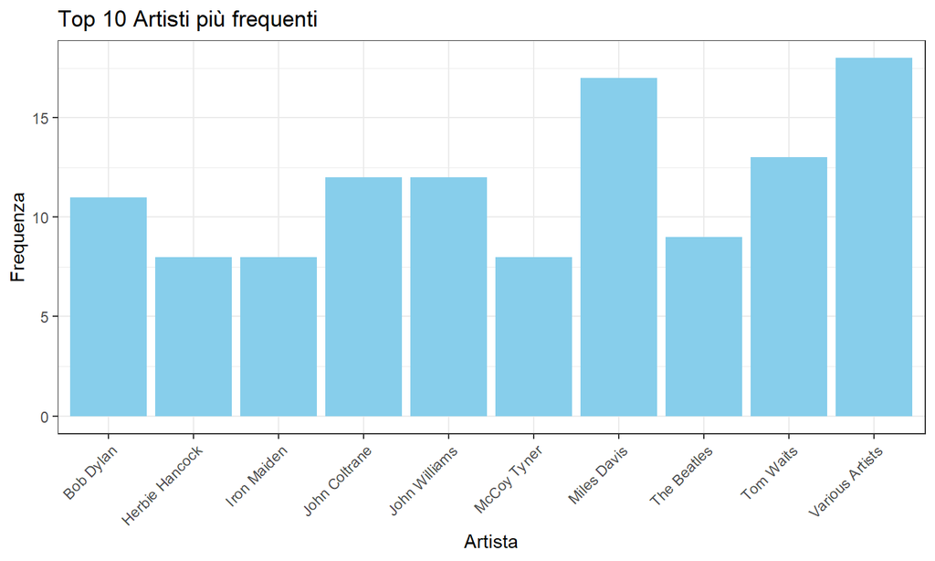

## Anno più produttivo

Andiamo a visualizzare un grafico che ci permetta di vedere l’andamento della produzione degli album nel corso dei decenni.

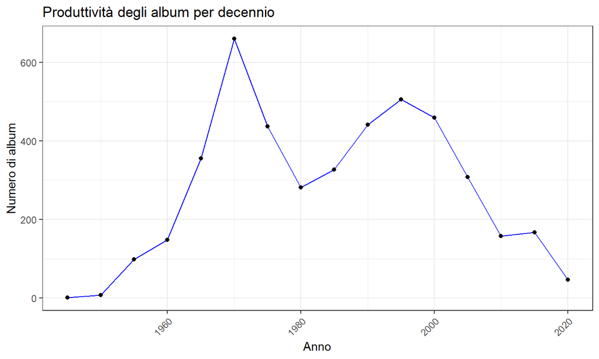

## Grafico dei generi

[figure not shown]

## Durata media degli Album nei Decenni

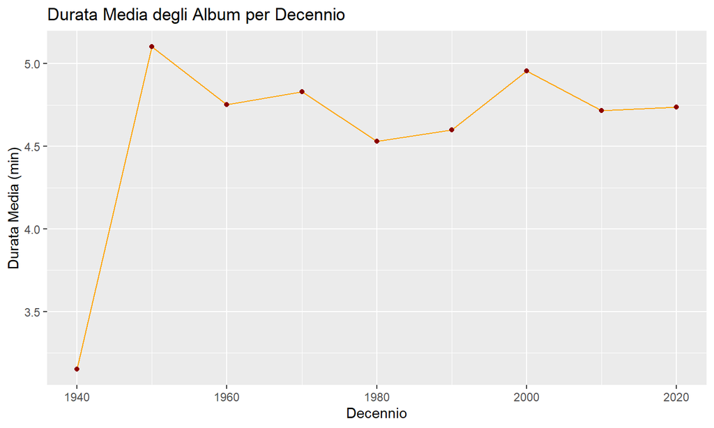

## Descrizioni più usate

[interactive chart not shown]

## Apprezzamento del pubblico

Andiamo a vedere come è variato il rating degli album nel tempo.

[figure not shown]

## Miles Davis

## Miles Davis viaggia nei sottogeneri del jazz

[interactive chart not shown]

## Andiamo a vedere le caratteristiche dei suoi album

Quanto sono ballabili?

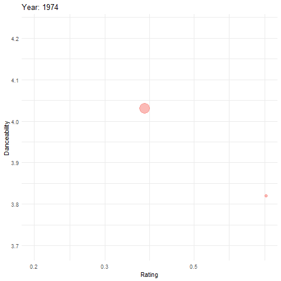

## Andiamo a vedere le caratteristiche dei suoi album

Si possono eseguire dal vivo?

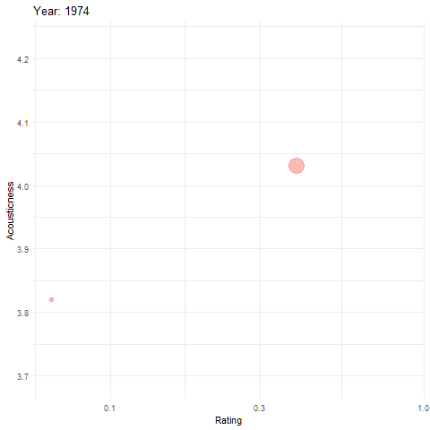

## Andiamo a vedere le caratteristiche dei suoi album

Quanta energia trasmettono?

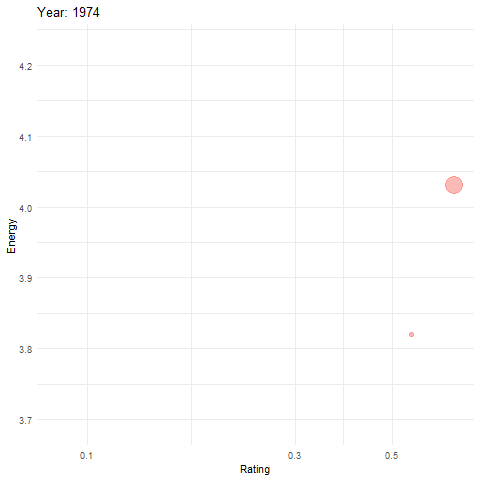

## Fonti

Il dataset da cui ho attinto le mie informazioni si può trovare su [kaggle](https://www.kaggle.com/datasets/lucascantu/top-5000-albums-of-all-time-spotify-features): https://www.kaggle.com/datasets/lucascantu/top-5000-albums-of-all-time-spotify-features